# Flights Data Exploration

## Preliminary Wrangling

> Briefly introduce your dataset here. This document explores a dataset containing flights information such as number of passengers and classes as well as other info that is related to around 114135 flights that have been taken.

```python
# import all packages and set plots to be embedded inline
import numpy as np
import pandas as pd
import matplotlib.pyplot as plt
import seaborn as sb

%matplotlib inline
```

> Load in your dataset and describe its properties through the questions below. Try and motivate your exploration goals through this section.

```python
flights = pd.read_csv('flights.csv')
flights.head()
```

|  | DEPARTURES_SCHEDULED | DEPARTURES_PERFORMED | PAYLOAD | SEATS | PASSENGERS | FREIGHT | MAIL | DISTANCE | UNIQUE_CARRIER | UNIQUE_CARRIER_NAME | ORIGIN_AIRPORT_ID | ORIGIN_CITY_NAME | DEST_AIRPORT_ID | DEST_CITY_NAME | AIRCRAFT_TYPE | MONTH | CLASS | Unnamed: 17 |
| --- | --- | --- | --- | --- | --- | --- | --- | --- | --- | --- | --- | --- | --- | --- | --- | --- | --- | --- |
| 0 | 0.0 | 1.0 | 21502.0 | 76.0 | 49.0 | 0.0 | 0.0 | 505.0 | 9E | Endeavor Air Inc. | 11433 | Detroit, MI | 10980 | Chattanooga, TN | 638 | 1 | F | NaN |
| 1 | 0.0 | 2.0 | 39002.0 | 146.0 | 65.0 | 0.0 | 0.0 | 166.0 | 9E | Endeavor Air Inc. | 11433 | Detroit, MI | 11267 | Dayton, OH | 638 | 1 | F | NaN |
| 2 | 0.0 | 4.0 | 86008.0 | 304.0 | 210.0 | 0.0 | 0.0 | 113.0 | 9E | Endeavor Air Inc. | 11433 | Detroit, MI | 10469 | Kalamazoo, MI | 638 | 1 | F | NaN |
| 3 | 0.0 | 1.0 | 21502.0 | 76.0 | 71.0 | 0.0 | 0.0 | 98.0 | 9E | Endeavor Air Inc. | 11433 | Detroit, MI | 13184 | Saginaw/Bay City/Midland, MI | 638 | 1 | F | NaN |
| 4 | 0.0 | 1.0 | 21502.0 | 76.0 | 45.0 | 0.0 | 0.0 | 363.0 | 9E | Endeavor Air Inc. | 11433 | Detroit, MI | 11203 | Mosinee, WI | 638 | 1 | F | NaN |

```python
flights.shape
```

```
(114135, 18)
```

```python
flights.info()
```

```
<class 'pandas.core.frame.DataFrame'>
RangeIndex: 114135 entries, 0 to 114134
Data columns (total 18 columns):
 #   Column                Non-Null Count   Dtype
---  ------                --------------   -----
 0   DEPARTURES_SCHEDULED  114135 non-null  float64
 1   DEPARTURES_PERFORMED  114135 non-null  float64
 2   PAYLOAD               114135 non-null  float64
 3   SEATS                 114135 non-null  float64
 4   PASSENGERS            114135 non-null  float64
 5   FREIGHT               114135 non-null  float64
 6   MAIL                  114135 non-null  float64
 7   DISTANCE              114135 non-null  float64
 8   UNIQUE_CARRIER        114135 non-null  object
 9   UNIQUE_CARRIER_NAME   114135 non-null  object
 10  ORIGIN_AIRPORT_ID     114135 non-null  int64
 11  ORIGIN_CITY_NAME      114135 non-null  object
 12  DEST_AIRPORT_ID       114135 non-null  int64
 13  DEST_CITY_NAME        114135 non-null  object
 14  AIRCRAFT_TYPE         114135 non-null  int64
 15  MONTH                 114135 non-null  int64
 16  CLASS                 114135 non-null  object
 17  Unnamed: 17           0 non-null       float64
dtypes: float64(9), int64(4), object(5)
memory usage: 15.7+ MB
```

```python
flights = flights.drop("Unnamed: 17", axis=1)
```

```python
flights.dtypes
```

```
DEPARTURES_SCHEDULED    float64
DEPARTURES_PERFORMED    float64
PAYLOAD                 float64
SEATS                   float64
PASSENGERS              float64
FREIGHT                 float64
MAIL                    float64
DISTANCE                float64
UNIQUE_CARRIER           object
UNIQUE_CARRIER_NAME      object
ORIGIN_AIRPORT_ID         int64
ORIGIN_CITY_NAME         object
DEST_AIRPORT_ID           int64
DEST_CITY_NAME           object
AIRCRAFT_TYPE             int64
MONTH                     int64
CLASS                    object
dtype: object
```

```python
flights.CLASS.value_counts()
```

```
F    88254
G    12106
L    10660
P     3115
Name: CLASS, dtype: int64
```

```python
flights['CLASS']=flights.CLASS.astype('category')
```

```python
flights.dtypes
```

```
DEPARTURES_SCHEDULED     float64
DEPARTURES_PERFORMED     float64
PAYLOAD                  float64
SEATS                    float64
PASSENGERS               float64
FREIGHT                  float64
MAIL                     float64
DISTANCE                 float64
UNIQUE_CARRIER            object
UNIQUE_CARRIER_NAME       object
ORIGIN_AIRPORT_ID          int64
ORIGIN_CITY_NAME          object
DEST_AIRPORT_ID            int64
DEST_CITY_NAME            object
AIRCRAFT_TYPE              int64
MONTH                      int64
CLASS                   category
dtype: object
```

```python
flights.UNIQUE_CARRIER_NAME.value_counts()
```

```
Southwest Airlines Co.            10261
Delta Air Lines Inc.               9420
United Air Lines Inc.              8828
SkyWest Airlines Inc.              8721
American Airlines Inc.             7261
                                  ...
City Wings Inc dba Seaflight          8
Mokulele Flight Services, Inc.        6
Katmai Air                            5
XTRA Airways                          3
Grand Canyon Helicopters              3
Name: UNIQUE_CARRIER_NAME, Length: 109, dtype: int64
```

```python
flights.AIRCRAFT_TYPE.value_counts()
```

```
614    12053
694     9672
673     8360
698     7020
612     7002
       ...
495        3
355        3
360        3
339        2
390        2
Name: AIRCRAFT_TYPE, Length: 130, dtype: int64
```

```python
flights.describe()
```

|  | DEPARTURES_SCHEDULED | DEPARTURES_PERFORMED | PAYLOAD | SEATS | PASSENGERS | FREIGHT | MAIL | DISTANCE | ORIGIN_AIRPORT_ID | DEST_AIRPORT_ID | AIRCRAFT_TYPE | MONTH |
| --- | --- | --- | --- | --- | --- | --- | --- | --- | --- | --- | --- | --- |
| count | 114135.000000 | 114135.000000 | 1.141350e+05 | 114135.000000 | 114135.000000 | 1.141350e+05 | 1.141350e+05 | 114135.000000 | 114135.000000 | 114135.000000 | 114135.000000 | 114135.000000 |
| mean | 22.476769 | 21.072493 | 7.294094e+05 | 2237.090358 | 1405.064581 | 7.297717e+04 | 3.225768e+03 | 740.276672 | 12762.279993 | 12757.205660 | 607.887116 | 2.315109 |
| std | 35.675542 | 32.538589 | 1.346144e+06 | 4349.572390 | 3141.885915 | 4.074025e+05 | 3.714811e+04 | 624.024282 | 1572.058122 | 1571.374415 | 162.225546 | 1.068566 |
| min | 0.000000 | 0.000000 | 0.000000e+00 | 0.000000 | 0.000000 | 0.000000e+00 | 0.000000e+00 | 0.000000 | 10006.000000 | 10006.000000 | 10.000000 | 1.000000 |
| 25% | 1.000000 | 2.000000 | 4.210000e+04 | 63.000000 | 7.000000 | 0.000000e+00 | 0.000000e+00 | 268.000000 | 11292.000000 | 11292.000000 | 614.000000 | 1.000000 |
| 50% | 8.000000 | 8.000000 | 2.200000e+05 | 480.000000 | 174.000000 | 0.000000e+00 | 0.000000e+00 | 600.000000 | 12889.000000 | 12889.000000 | 631.000000 | 2.000000 |
| 75% | 30.000000 | 28.000000 | 8.816000e+05 | 2737.000000 | 1473.000000 | 1.510500e+03 | 0.000000e+00 | 1020.000000 | 14100.000000 | 14100.000000 | 694.000000 | 3.000000 |
| max | 1108.000000 | 1108.000000 | 3.173940e+07 | 102784.000000 | 79919.000000 | 2.242442e+07 | 3.616267e+06 | 7247.000000 | 16883.000000 | 16883.000000 | 889.000000 | 4.000000 |

### What is the structure of your dataset?

There are 114135 flights in the dataframe, with different seat counts for each flight and different classes, the classes were not explained in the website that the data was extracted from, hwoever, I did some digging and was able to infer the meaning according to cheapflights.ca for each class abbreviation:

F: Full First Class

P: Discounted First Class

L: Business

G: Economy

### What is/are the main feature(s) of interest in your dataset?

What aspects effect the passengers and the passenger/seats ratio?

### What features in the dataset do you think will help support your investigation into your feature(s) of interest?

I believe that the departure and destination cities as well as the flight carriers will have an effect on the number of passengers. We should also take considration of what type of class people usually choose.

## Univariate Exploration

> In this section, investigate distributions of individual variables. If you see unusual points or outliers, take a deeper look to clean things up and prepare yourself to look at relationships between variables.

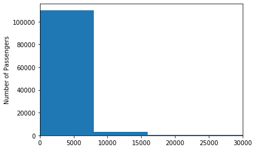

```python
bins = np.arange(0, flights['PASSENGERS'].max()+1000, 1000)
plt.hist(data = flights, x = 'PASSENGERS');
plt.ylabel('Number of Passengers')
plt.xlim((0,30000));
```

This visual gives us the number of passengers as a total, however it is not vary helpfull to just know the number of passengers. A more interesting graph could be achived if we know the ratio of seats availabe to the passengers that took those seats, that way we could know what percentage of the aircrafts is mostly accouring when visualizing that ratio. So we will create a new column that contains the passenger/seat ratio.

```python
flights['Passenger_Seat_Ratio'] = flights.PASSENGERS.div(flights.SEATS)
flights.Passenger_Seat_Ratio.value_counts()
```

```
0.000000    7320
1.000000     688
0.333333     570
0.500000     476
0.166667     424
            ...
0.485215       1
0.151596       1
0.089048       1
0.472674       1
0.898010       1
Name: Passenger_Seat_Ratio, Length: 52979, dtype: int64
```

```python
flights = flights.query('Passenger_Seat_Ratio <= 1')
```

```python
flights.Passenger_Seat_Ratio.value_counts()
```

```
0.000000    7320
1.000000     688
0.333333     570
0.500000     476
0.166667     424
            ...
0.555622       1
0.657837       1
0.840007       1
0.807459       1
0.788064       1
Name: Passenger_Seat_Ratio, Length: 52977, dtype: int64
```

```python
flights.head(10)
```

|  | DEPARTURES_SCHEDULED | DEPARTURES_PERFORMED | PAYLOAD | SEATS | PASSENGERS | FREIGHT | MAIL | DISTANCE | UNIQUE_CARRIER | UNIQUE_CARRIER_NAME | ORIGIN_AIRPORT_ID | ORIGIN_CITY_NAME | DEST_AIRPORT_ID | DEST_CITY_NAME | AIRCRAFT_TYPE | MONTH | CLASS | Passenger_Seat_Ratio |
| --- | --- | --- | --- | --- | --- | --- | --- | --- | --- | --- | --- | --- | --- | --- | --- | --- | --- | --- |
| 0 | 0.0 | 1.0 | 21502.0 | 76.0 | 49.0 | 0.0 | 0.0 | 505.0 | 9E | Endeavor Air Inc. | 11433 | Detroit, MI | 10980 | Chattanooga, TN | 638 | 1 | F | 0.644737 |
| 1 | 0.0 | 2.0 | 39002.0 | 146.0 | 65.0 | 0.0 | 0.0 | 166.0 | 9E | Endeavor Air Inc. | 11433 | Detroit, MI | 11267 | Dayton, OH | 638 | 1 | F | 0.445205 |
| 2 | 0.0 | 4.0 | 86008.0 | 304.0 | 210.0 | 0.0 | 0.0 | 113.0 | 9E | Endeavor Air Inc. | 11433 | Detroit, MI | 10469 | Kalamazoo, MI | 638 | 1 | F | 0.690789 |
| 3 | 0.0 | 1.0 | 21502.0 | 76.0 | 71.0 | 0.0 | 0.0 | 98.0 | 9E | Endeavor Air Inc. | 11433 | Detroit, MI | 13184 | Saginaw/Bay City/Midland, MI | 638 | 1 | F | 0.934211 |
| 4 | 0.0 | 1.0 | 21502.0 | 76.0 | 45.0 | 0.0 | 0.0 | 363.0 | 9E | Endeavor Air Inc. | 11433 | Detroit, MI | 11203 | Mosinee, WI | 638 | 1 | F | 0.592105 |
| 5 | 0.0 | 1.0 | 21502.0 | 76.0 | 47.0 | 0.0 | 0.0 | 363.0 | 9E | Endeavor Air Inc. | 11433 | Detroit, MI | 11612 | Evansville, IN | 638 | 1 | F | 0.618421 |
| 6 | 0.0 | 1.0 | 21502.0 | 76.0 | 17.0 | 0.0 | 0.0 | 306.0 | 9E | Endeavor Air Inc. | 11433 | Detroit, MI | 14730 | Louisville, KY | 638 | 1 | F | 0.223684 |
| 7 | 0.0 | 1.0 | 21502.0 | 76.0 | 53.0 | 0.0 | 0.0 | 173.0 | 9E | Endeavor Air Inc. | 11193 | Cincinnati, OH | 11146 | Charleston/Dunbar, WV | 638 | 1 | F | 0.697368 |
| 8 | 0.0 | 1.0 | 21502.0 | 76.0 | 1.0 | 0.0 | 0.0 | 335.0 | 9E | Endeavor Air Inc. | 11193 | Cincinnati, OH | 11057 | Charlotte, NC | 638 | 1 | F | 0.013158 |
| 9 | 0.0 | 2.0 | 35000.0 | 140.0 | 30.0 | 0.0 | 0.0 | 539.0 | 9E | Endeavor Air Inc. | 11193 | Cincinnati, OH | 13198 | Kansas City, MO | 638 | 1 | F | 0.214286 |

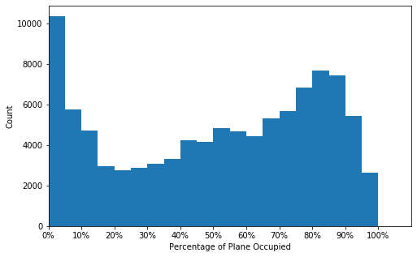

```python
binsize = 0.05
bins = np.arange(0, flights['Passenger_Seat_Ratio'].max()+binsize, binsize)
plt.figure(figsize=[8, 5])
plt.hist(data = flights, x = 'Passenger_Seat_Ratio', bins = bins);
plt.xticks([0.0, 0.1, 0.2, 0.3, 0.4, 0.5, 0.6, 0.7, 0.8, 0.9, 1],
           ['0%', '10%', '20%','30%', '40%', '50%', '60%', '70%', '80%', '90%', '100%'])
plt.ylabel('Count')
plt.xlabel('Percentage of Plane Occupied')
plt.xlim((0,1.1));
```

```python
flights.query('Passenger_Seat_Ratio == 0')
```

|  | DEPARTURES_SCHEDULED | DEPARTURES_PERFORMED | PAYLOAD | SEATS | PASSENGERS | FREIGHT | MAIL | DISTANCE | UNIQUE_CARRIER | UNIQUE_CARRIER_NAME | ORIGIN_AIRPORT_ID | ORIGIN_CITY_NAME | DEST_AIRPORT_ID | DEST_CITY_NAME | AIRCRAFT_TYPE | MONTH | CLASS | Passenger_Seat_Ratio |
| --- | --- | --- | --- | --- | --- | --- | --- | --- | --- | --- | --- | --- | --- | --- | --- | --- | --- | --- |
| 17 | 0.0 | 1.0 | 21502.0 | 76.0 | 0.0 | 0.0 | 0.0 | 524.0 | 9E | Endeavor Air Inc. | 13367 | Moline, IL | 15412 | Knoxville, TN | 638 | 1 | F | 0.0 |
| 33 | 0.0 | 1.0 | 17500.0 | 70.0 | 0.0 | 0.0 | 0.0 | 375.0 | 9E | Endeavor Air Inc. | 13487 | Minneapolis, MN | 10685 | Bloomington/Normal, IL | 638 | 1 | F | 0.0 |
| 88 | 0.0 | 1.0 | 12500.0 | 50.0 | 0.0 | 0.0 | 0.0 | 292.0 | 9E | Endeavor Air Inc. | 12953 | New York, NY | 10792 | Buffalo, NY | 629 | 1 | F | 0.0 |
| 107 | 0.0 | 1.0 | 18800.0 | 69.0 | 0.0 | 0.0 | 0.0 | 264.0 | 9E | Endeavor Air Inc. | 13930 | Chicago, IL | 11193 | Cincinnati, OH | 631 | 1 | F | 0.0 |
| 132 | 0.0 | 1.0 | 27855.0 | 60.0 | 0.0 | 0.0 | 0.0 | 100.0 | AMQ | Ameristar Air Cargo | 15016 | St. Louis, MO | 11111 | Columbia, MO | 620 | 1 | L | 0.0 |
| ... | ... | ... | ... | ... | ... | ... | ... | ... | ... | ... | ... | ... | ... | ... | ... | ... | ... | ... |
| 100043 | 56.0 | 1.0 | 2000.0 | 8.0 | 0.0 | 0.0 | 0.0 | 123.0 | 4B | Boutique Air | 12266 | Houston, TX | 15569 | Victoria, TX | 458 | 3 | F | 0.0 |
| 102182 | 60.0 | 14.0 | 25200.0 | 126.0 | 0.0 | 0.0 | 0.0 | 17.0 | VI | Vieques Air Link Inc. | 11126 | Culebra, PR | 15626 | Vieques, PR | 131 | 4 | F | 0.0 |
| 102183 | 60.0 | 14.0 | 25200.0 | 126.0 | 0.0 | 0.0 | 0.0 | 17.0 | VI | Vieques Air Link Inc. | 15626 | Vieques, PR | 11126 | Culebra, PR | 131 | 4 | F | 0.0 |
| 102184 | 60.0 | 4.0 | 7200.0 | 36.0 | 0.0 | 0.0 | 0.0 | 47.0 | VI | Vieques Air Link Inc. | 14843 | San Juan, PR | 11126 | Culebra, PR | 131 | 4 | F | 0.0 |
| 108776 | 90.0 | 4.0 | 7200.0 | 36.0 | 0.0 | 0.0 | 0.0 | 47.0 | VI | Vieques Air Link Inc. | 11126 | Culebra, PR | 14843 | San Juan, PR | 131 | 4 | F | 0.0 |

7320 rows × 18 columns

There is nothing special to note about these empty flights, the probable assumption we could make about them is that they are returning flights after completing a trip.

Lets check the months that most flights where held in. But first, we will change the labels of these months such that they would become more readable.

```python
flights['MONTH']=flights['MONTH'].replace(1, 'January')
flights['MONTH']=flights['MONTH'].replace(2, 'February')
flights['MONTH']=flights['MONTH'].replace(3, 'March')
flights['MONTH']=flights['MONTH'].replace(4, 'April')
```

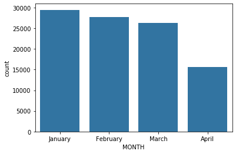

```python
fig = plt.figure()
ax = fig.add_axes([.125, .125, .775, .755])
base_color = sb.color_palette()[0]
sb.countplot(data = flights, x = 'MONTH', color = base_color, ax = ax);
```

We get a really interesting visualization here that shows us the drastic fall of number of flights in April compared to those in January, this is mostly due to flight restrictions that accord at time from March to April because of the COVID-19 viruse.

Let us check the classes that are most chosen by people, and again these class definitons were derived from the cheapflights.ca website, here is the link for the article https://www.cheapflights.ca/news/what-are-airline-classes.

We will also make sure that these service classes are readable.

```python
flights['CLASS']=flights['CLASS'].replace('F', 'Full First')
flights['CLASS']=flights['CLASS'].replace('G', 'Economy')
flights['CLASS']=flights['CLASS'].replace('L', 'Business')
flights['CLASS']=flights['CLASS'].replace('P', 'Discounted First')
```

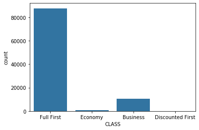

```python
fig = plt.figure()
ax = fig.add_axes([.125, .125, .775, .755])
base_color = sb.color_palette()[0]
sb.countplot(data = flights, x = 'CLASS', color = base_color, ax = ax);
```

What we find here is an interesting observation, most people tend to go on Full First class, followed by Business class. Almost no one uses the Discounted First class.

Now, let us check what carrier airlines people tend to travel on.

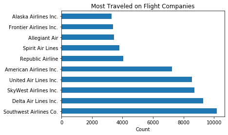

```python
flights.UNIQUE_CARRIER_NAME.value_counts().head(10).plot(kind='barh', title = 'Most Traveled on Flight Companies');
plt.xlabel('Count')
```

It seems that the top airlines that people tend to travel on are Southwest Airlines, Delta Airlines, SkyWest Airlines, United Airlines and American Airlines. This by all means does not indicate that these airlines are the most likable, it just state's that these are the airlines that have the most travel records.

### Of the features you investigated, were there any unusual distributions? Did you perform any operations on the data to tidy, adjust, or change the form of the data? If so, why did you do this?

I needed to change the labels for some of the columns to make them more readable, like the month names and the flight classes. I also had to add a column for the ratio of passengers/seats to find a more logical visual rather than using the raw data of passengers.

## Bivariate Exploration

```python
flights.head()
```

|  | DEPARTURES_SCHEDULED | DEPARTURES_PERFORMED | PAYLOAD | SEATS | PASSENGERS | FREIGHT | MAIL | DISTANCE | UNIQUE_CARRIER | UNIQUE_CARRIER_NAME | ORIGIN_AIRPORT_ID | ORIGIN_CITY_NAME | DEST_AIRPORT_ID | DEST_CITY_NAME | AIRCRAFT_TYPE | MONTH | CLASS | Passenger_Seat_Ratio |
| --- | --- | --- | --- | --- | --- | --- | --- | --- | --- | --- | --- | --- | --- | --- | --- | --- | --- | --- |
| 0 | 0.0 | 1.0 | 21502.0 | 76.0 | 49.0 | 0.0 | 0.0 | 505.0 | 9E | Endeavor Air Inc. | 11433 | Detroit, MI | 10980 | Chattanooga, TN | 638 | January | Full First | 0.644737 |
| 1 | 0.0 | 2.0 | 39002.0 | 146.0 | 65.0 | 0.0 | 0.0 | 166.0 | 9E | Endeavor Air Inc. | 11433 | Detroit, MI | 11267 | Dayton, OH | 638 | January | Full First | 0.445205 |
| 2 | 0.0 | 4.0 | 86008.0 | 304.0 | 210.0 | 0.0 | 0.0 | 113.0 | 9E | Endeavor Air Inc. | 11433 | Detroit, MI | 10469 | Kalamazoo, MI | 638 | January | Full First | 0.690789 |
| 3 | 0.0 | 1.0 | 21502.0 | 76.0 | 71.0 | 0.0 | 0.0 | 98.0 | 9E | Endeavor Air Inc. | 11433 | Detroit, MI | 13184 | Saginaw/Bay City/Midland, MI | 638 | January | Full First | 0.934211 |
| 4 | 0.0 | 1.0 | 21502.0 | 76.0 | 45.0 | 0.0 | 0.0 | 363.0 | 9E | Endeavor Air Inc. | 11433 | Detroit, MI | 11203 | Mosinee, WI | 638 | January | Full First | 0.592105 |

Let's use a heatmap to check if there is any notable correlations between any two numerical variables.

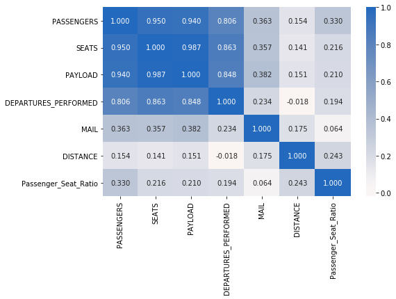

```python
numeric_vars = ['PASSENGERS', 'SEATS', 'PAYLOAD', 'DEPARTURES_PERFORMED','MAIL', 'DISTANCE', 'Passenger_Seat_Ratio']
plt.figure(figsize = [8, 5])
sb.heatmap(flights[numeric_vars].corr(), annot = True, fmt = '.3f',
           cmap = 'vlag_r', center = 0)
plt.show()
```

At first glance the number of correlations here is overwhelming. However, if we take a closer look it doesn't appear that way anymore. As most of the correlations here are logical and need no further investigation. Specifically the correlations between passengers, seats, payload and departures performed. It follows that if the number of seats increase then the number of passengers will increase as will as the payload that the flight could handle. The same could be said for the ratio, because the ratio in the end depends on the number of passengers and seats. The only correlations that might be worth checking is the relation between the distance and other variables. The mail might also render some interesting insights. Some of these values will be checked here in the bivariate exploration while others will be expolred in the multivariate exploration.

Let us now check if there are any interesting correlations to make with some of the categorical variables such as the carrier company, the month and the class.

Let's start with the carrier companies, there are so many carrier companies, so we will choose the top 5 of them with the most flight trips.

```python
flights.UNIQUE_CARRIER_NAME.value_counts().head(10)
```

```
Southwest Airlines Co.    10190
Delta Air Lines Inc.       9304
SkyWest Airlines Inc.      8721
United Air Lines Inc.      8569
American Airlines Inc.     7259
Republic Airline           4043
Spirit Air Lines           3797
Allegiant Air              3458
Frontier Airlines Inc.     3387
Alaska Airlines Inc.       3276
Name: UNIQUE_CARRIER_NAME, dtype: int64
```

The most traveled on airlines are Southwest Airlines, followed by Delta Airlines, followed by SkyWest Airlines, followed by United and American Airlines respectively.

Let's isolate these top five airlines into a dataset.

```python
top_carriers = flights.UNIQUE_CARRIER_NAME.apply(lambda x: 'Southwest Airlines Co.' if x in
    'Southwest Airlines Co.' else 'Delta Air Lines Inc.' if x in
    'Delta Air Lines Inc.' else 'SkyWest Airlines Inc.' if x in
    'SkyWest Airlines Inc.' else 'United Air Lines Inc.' if x in
    'United Air Lines Inc.'  else 'American Airlines Inc.' if x in
    'American Airlines Inc.' else np.nan)
top_carriers.value_counts()
```

```
Southwest Airlines Co.    10190
Delta Air Lines Inc.       9304
SkyWest Airlines Inc.      8721
United Air Lines Inc.      8569
American Airlines Inc.     7259
Name: UNIQUE_CARRIER_NAME, dtype: int64
```

Now let us find out what class would people like to board in these top five airlines.

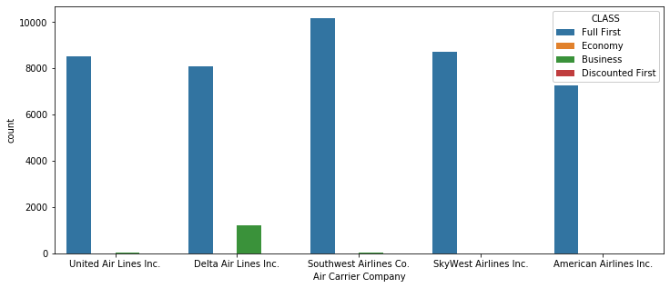

```python
plt.figure(figsize=[12, 5])
ax = sb.countplot(data = flights, x = top_carriers, hue = 'CLASS')
ax.legend(loc = 1, ncol = 1, framealpha = 1, title = 'CLASS')
plt.xlabel('Air Carrier Company');
```

Interesting, it seems that in these top airlines, people tend to choose Full First classes. However, if we take a look at Delta Airlines, we see that a small contingent would go with the Business class, maybe Delat Airlines have some special services provided for those who would board the business class.

What about the mail? are they also correlated with passenger count? Let's check the number of mails by month

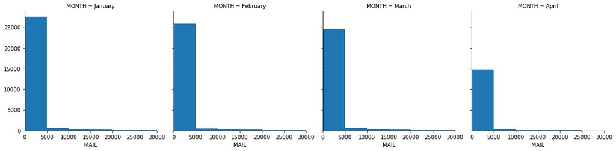

```python
bin_edges = np.arange(0, flights['MAIL'].max()+5000, 5000)

g = sb.FacetGrid(data = flights, col = 'MONTH',
                margin_titles = True, size = 4)
g.map(plt.hist, "MAIL",bins=bin_edges)
plt.xlim((0,30000));
```

So there also is a correlation between the number of mails and the number of passengers, and that is completely logical because most mails tend to be people's loggages.

We also want to know how the ratio of passengers/seats differ for each airline.

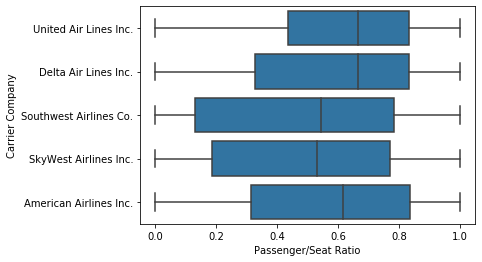

```python
base_color = sb.color_palette()[0]
sb.boxplot(data = flights, x = 'Passenger_Seat_Ratio', y = top_carriers, color = base_color)
plt.xlabel('Passenger/Seat Ratio')
plt.ylabel('Carrier Company');
```

We can see that the ratio range differ from airline to airline. Southwest Airlines has a wide range when talking about that ratio, ranging from 20%-80% of the flights being full. while the United Airlines range form about 50%-85%(which might indicate that the United Airlines is more succesfull in making sure that they sell a higher rate of seats compared to Southwest Airlines).

Now let us check what cities have the most departures and arrivals.

```python
flights.ORIGIN_CITY_NAME.value_counts().head(20)
```

```
Chicago, IL              4680
Denver, CO               3336
Atlanta, GA              2912
Houston, TX              2674
Washington, DC           2566
Dallas/Fort Worth, TX    2321
New York, NY             2044
Detroit, MI              2029
Phoenix, AZ              2029
Los Angeles, CA          1982
Charlotte, NC            1977
Minneapolis, MN          1903
Las Vegas, NV            1773
Orlando, FL              1764
Seattle, WA              1720
Newark, NJ               1592
Philadelphia, PA         1520
San Francisco, CA        1466
Salt Lake City, UT       1260
Boston, MA               1255
Name: ORIGIN_CITY_NAME, dtype: int64
```

```python
flights.DEST_CITY_NAME.value_counts().head(20)
```

```
Chicago, IL              4746
Denver, CO               3396
Atlanta, GA              2958
Houston, TX              2739
Washington, DC           2574
Dallas/Fort Worth, TX    2365
New York, NY             2043
Detroit, MI              2016
Phoenix, AZ              1997
Charlotte, NC            1969
Los Angeles, CA          1929
Minneapolis, MN          1902
Las Vegas, NV            1781
Orlando, FL              1734
Seattle, WA              1719
Newark, NJ               1608
Philadelphia, PA         1532
San Francisco, CA        1473
Fort Lauderdale, FL      1254
Salt Lake City, UT       1249
Name: DEST_CITY_NAME, dtype: int64
```

There is not much difference between the number of departures and arrivals, so we will stick with the departures.

```python
top_origin = flights.ORIGIN_CITY_NAME.apply(lambda x: 'Chicago, IL' if x in
    'Chicago, IL' else 'Denver, CO' if x in
    'Denver, CO' else 'Atlanta, GA' if x in
    'Atlanta, GA'  else 'Houston, TX' if x in
    'Houston, TX' else 'Washington, DC' if x in
    'Washington, DC' else np.nan)
top_origin.value_counts()
```

```
Chicago, IL       4680
Denver, CO        3336
Atlanta, GA       2912
Houston, TX       2674
Washington, DC    2566
Name: ORIGIN_CITY_NAME, dtype: int64
```

So the cities that have most flight departers are by order: Chicago, Denver, Atlanta, Houston and Washington.

We will now check the relation between the cities and flight passenger/seat ratio.

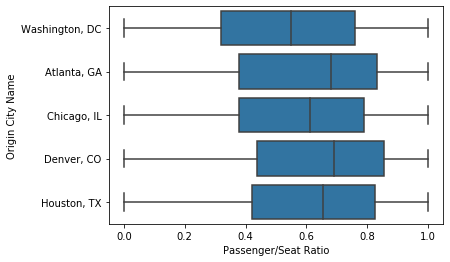

```python
base_color = sb.color_palette()[0]
sb.boxplot(data = flights, x = 'Passenger_Seat_Ratio', y = top_origin, color = base_color)
plt.ylabel('Origin City Name')
plt.xlabel('Passenger/Seat Ratio');
```

It seems that most if these cities have a ratio ranging from 0.4 up to 0.8. Meaning that most flights coming from these cities have 40%-80% of their seats occupied.

### Talk about some of the relationships you observed in this part of the investigation. How did the feature(s) of interest vary with other features in the dataset?

I found that the fact that most passengers would rather ride flights with first class interesting. Also, the ratio of passenger/seat varying based on the carrier company gives us an insight that not always the airlines with the most travels automatically mean that they are successful, as we saw with the case of United and SouthWest airlines.

### Did you observe any interesting relationships between the other features (not the main feature(s) of interest)?

I think that the decline of the number of mails transformed through flights in the short period of 4 months is astonishing, this again proves how the Covid-19 pandemic affected the flight industry in a very negative manner

## Multivariate Exploration

```python
flights.head()
```

|  | DEPARTURES_SCHEDULED | DEPARTURES_PERFORMED | PAYLOAD | SEATS | PASSENGERS | FREIGHT | MAIL | DISTANCE | UNIQUE_CARRIER | UNIQUE_CARRIER_NAME | ORIGIN_AIRPORT_ID | ORIGIN_CITY_NAME | DEST_AIRPORT_ID | DEST_CITY_NAME | AIRCRAFT_TYPE | MONTH | CLASS | Passenger_Seat_Ratio |
| --- | --- | --- | --- | --- | --- | --- | --- | --- | --- | --- | --- | --- | --- | --- | --- | --- | --- | --- |
| 0 | 0.0 | 1.0 | 21502.0 | 76.0 | 49.0 | 0.0 | 0.0 | 505.0 | 9E | Endeavor Air Inc. | 11433 | Detroit, MI | 10980 | Chattanooga, TN | 638 | January | Full First | 0.644737 |
| 1 | 0.0 | 2.0 | 39002.0 | 146.0 | 65.0 | 0.0 | 0.0 | 166.0 | 9E | Endeavor Air Inc. | 11433 | Detroit, MI | 11267 | Dayton, OH | 638 | January | Full First | 0.445205 |
| 2 | 0.0 | 4.0 | 86008.0 | 304.0 | 210.0 | 0.0 | 0.0 | 113.0 | 9E | Endeavor Air Inc. | 11433 | Detroit, MI | 10469 | Kalamazoo, MI | 638 | January | Full First | 0.690789 |
| 3 | 0.0 | 1.0 | 21502.0 | 76.0 | 71.0 | 0.0 | 0.0 | 98.0 | 9E | Endeavor Air Inc. | 11433 | Detroit, MI | 13184 | Saginaw/Bay City/Midland, MI | 638 | January | Full First | 0.934211 |
| 4 | 0.0 | 1.0 | 21502.0 | 76.0 | 45.0 | 0.0 | 0.0 | 363.0 | 9E | Endeavor Air Inc. | 11433 | Detroit, MI | 11203 | Mosinee, WI | 638 | January | Full First | 0.592105 |

Let us check the relation between the distance, passengers and ratio, since these three values would render an interesting correlation if we found one.

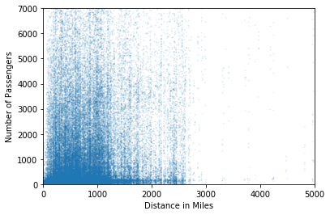

```python
plt.scatter(data = flights, x = 'DISTANCE', y = 'PASSENGERS', s = 'Passenger_Seat_Ratio', alpha= 1/10)

# dummy series for adding legend

base_color = sb.color_palette()[0]
plt.xlim(0,5000)
plt.ylabel('Number of Passengers')
plt.xlabel('Distance in Miles')
plt.ylim(0,7000);
```

The heatmap in the bivariate exploratin tells us that we should check the relations between the distance, the ratio and mails transformed, since the other correlations in the heatmap are rational and do not harber any new insights.

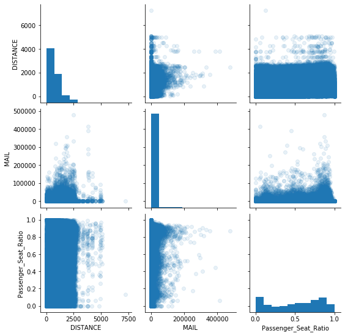

```python
g = sb.PairGrid(data = flights, vars = ['DISTANCE', 'MAIL', 'Passenger_Seat_Ratio'])
g.map_diag(plt.hist)
g.map_offdiag(plt.scatter,alpha=1/10);
```

Here we can find some intriguing insights. First off, we can see the the number of mails increases when the distance increases, however, when the distance starts to break the 2500 miles mark, the number of mails drasticlly decreases. We can also see that the number of mails increase when the passenger/seat ratio increases, which makes sense becuase more passengers in the plane means more loggage.

Finally, lets check the relation between the two categorical variables, presented by the month and class, and one numerical variable presented by the ratio. It would be interesting to see what month has the highst and lowest passenger/seat ratio while looking at the class choices at the same time.

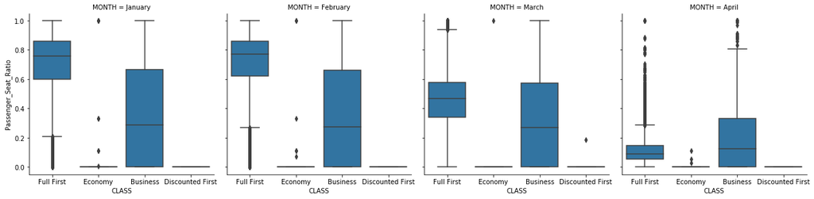

```python
g = sb.FacetGrid(data = flights, col = 'MONTH', height = 4.4,
                margin_titles = True)
plt.ylabel('Number of Passengers')
g.map(sb.boxplot, 'CLASS', 'Passenger_Seat_Ratio');
```

So there is some interesting information here regarding the classes and their relation with the months and ratio. In January, most of the people who rode on first class, had their planes 60%-80% occupied, with the median around 75%, while in Business the ratio was ranging from 0% all the way to 65%, with a median at around 30%. In February not much change was noted. In March, ratio range for the first class dropped from 60%-80% down to 35%-60%. On April the ratio range for the first class became even worse, dropping down to the range of 5%-15%. Business class also dropped to the 0%-35% range. It is interesting how in the fourth month business class passenger/seat ratio became higher than the full first in just 4 months

### Were there any interesting or surprising interactions between features?

One interesting insight is the fact that the number of mails transfered through flight decreases after the 2500 miles mark after increasing before that mark.

> At the end of your report, make sure that you export the notebook as an html file from the `File > Download as... > HTML` menu. Make sure you keep track of where the exported file goes, so you can put it in the same folder as this notebook for project submission. Also, make sure you remove all of the quote-formatted guide notes like this one before you finish your report!

```python
from subprocess import call
call(['python', '-m', 'nbconvert', 'Investigate_a_Dataset.ipynb'])
```